# 從高端疫苗股價的數據分析看COVID-19對生技業的影響

## 研究動機

本研究秉持著這個想法，以個股高端疫苗(6547)代表臺灣生技產業，對其進行股價的數據分析、比較大盤、新增確診人數等，想以一套科學的邏輯驗證方法，去檢驗民眾普遍認知「臺灣生技產業獲益於COVID-19」是否正確。

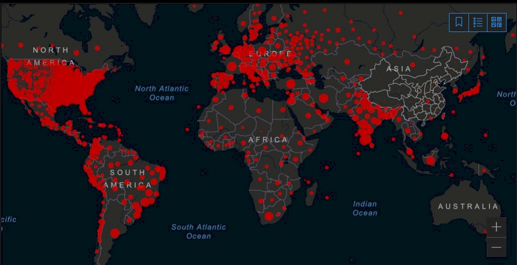

COVID-19 全球確診分布圖

## 研究摘要

> 假設：臺灣生技產業獲益於COVID-19

> 驗證：以高端疫苗(6547)股價對照台股大盤指數、新增確診人數進行推論

說明：

1.`「臺灣生技產業」`：若要以高端疫苗(6547)代表台灣生技產業，必須檢驗高端疫苗(6547)對生技類股具有代表性。

2.`「獲益」`： (1)用高端疫苗(6547)個股技術指標判斷，疫情期間以來長期呈現看漲訊號。 (2)高端疫苗(6547)和台股大盤指數進行比較，報酬率勝過大盤。

3.`「於COVID-19」`：若是起因於COVID-19的影響，那高端疫苗(6547)股價和新增確診人數必須具有一定相關性。

## 研究方法

Step 1：

驗證高端疫苗(6547)對生技業類股有高度相關性 → 將高端疫苗(6547)和生技業類股股價進行`單變數迴歸分析` → 若高度相關，則高端疫苗(6547)可以代表生技業進行數據分析。

Step 2：

驗證個股高端疫苗(6547)在疫情期間股價呈現看漲趨勢 → 描繪及分析其`K線圖、均線圖、ADX、ROC等技術指標` → 若呈現看漲趨勢，則高端疫苗(6547)在疫情期間獲利。

Step 3：

驗證高端疫苗(6547)對照台股大盤指數有較高的報酬率 → 計算及描繪出兩者的`報酬率對照折線圖` → 若報酬率較高，則高端疫苗(6547)在疫情期間獲利。

Step 4：

驗證高端疫苗(6547)股價和COVID-19全球新增確診人數成高度相關性 → 將高端疫苗(6547)股價和COVID-19全球新增確診人數進行`單變數迴歸分析` → 若高度相關，則高端疫苗(6547)股價受到COVID-19影響

## Step 1 高端疫苗對生技業類股有高度相關性

**流程架構**

為了驗證高端疫苗與生技業類股的相關性，將兩者的股價關係描繪出**點狀圖**及進行**單變數迴歸分析**。

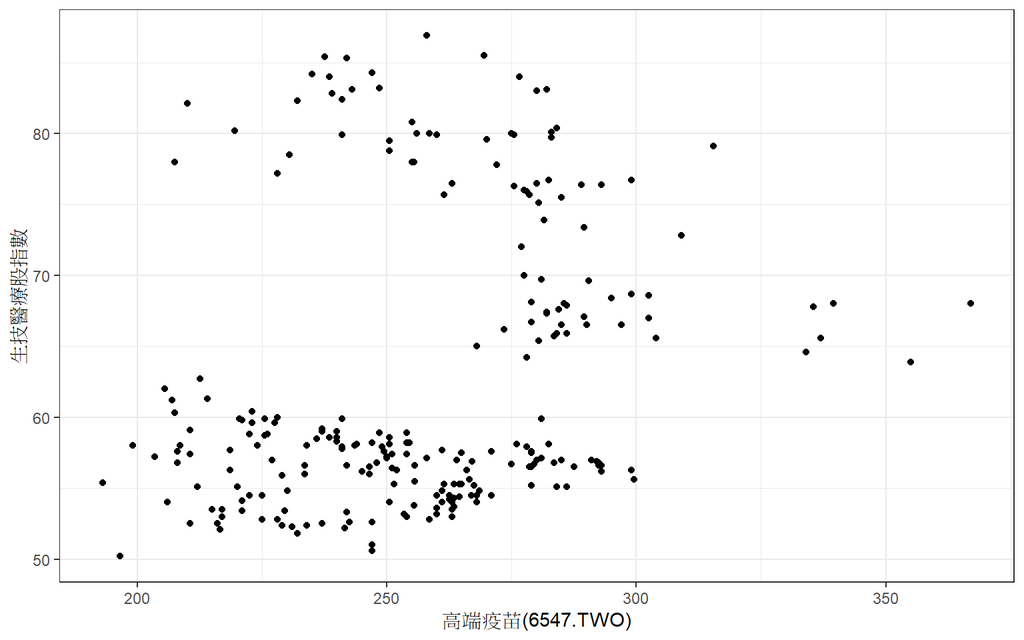

```
##
## Call:
## lm(formula = biology ~ medigen, data = representative.df)
##
## Residuals:
##     Min      1Q  Median      3Q     Max
## -11.274  -7.496  -3.561   2.814  24.317
##
## Coefficients:
##             Estimate Std. Error t value Pr(>|t|)
## (Intercept) 41.31081    5.38983   7.665 4.33e-13 ***
## medigen      0.08325    0.02081   4.001 8.37e-05 ***
## ---
## Signif. codes:  0 '***' 0.001 '**' 0.01 '*' 0.05 '.' 0.1 ' ' 1
##
## Residual standard error: 9.664 on 242 degrees of freedom
## Multiple R-squared:  0.06206,    Adjusted R-squared:  0.05818
## F-statistic: 16.01 on 1 and 242 DF,  p-value: 8.373e-05
```

## Step 2 高端疫苗在疫情期間股價呈現看漲趨勢

**流程架構**

為了驗證高端疫苗在疫情期間股價呈現看漲趨勢，擷取去年6月至今一年的歷史數據進行技術分析，描繪其**K線圖、均線圖、ADX、ROC**等(因受限於篇幅ADX、ROC補充在其他/附錄)。

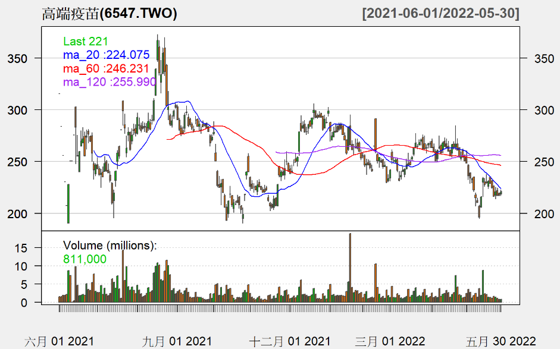

高端疫苗技術分析圖

**結果分析**

分析高端疫苗的均線圖，雖然從去年6月到9月K線一飛衝天，但在10月經歷第一次死亡交叉之後，股價便掉回原先200元低點，一路漲漲跌跌直到12月突破60MA回到300點，之後就在250~300之間徘徊。而在今年4月底台灣疫情爆發時，20MA陸續跌破120MA、60MA回到一開始的200點。

所以從均線技術分析看出*高端疫苗股價時漲時跌，沒有因為疫情而有明顯獲利*。

## Step 3 高端疫苗對照台股大盤指數有較高的報酬率

**流程架構**

為了驗證高端疫苗比台股大盤指數有較高的報酬率，分別計算兩者的日報酬率並描繪其**日報酬率折線圖**(見其他/附錄)。因為無法從日報酬率折線圖中明顯看出兩者報酬率高低，所以更進一步將高端疫苗日報酬率減去台股大盤指數日報酬率，計算出**高端疫苗淨日報酬率圖**進行分析。

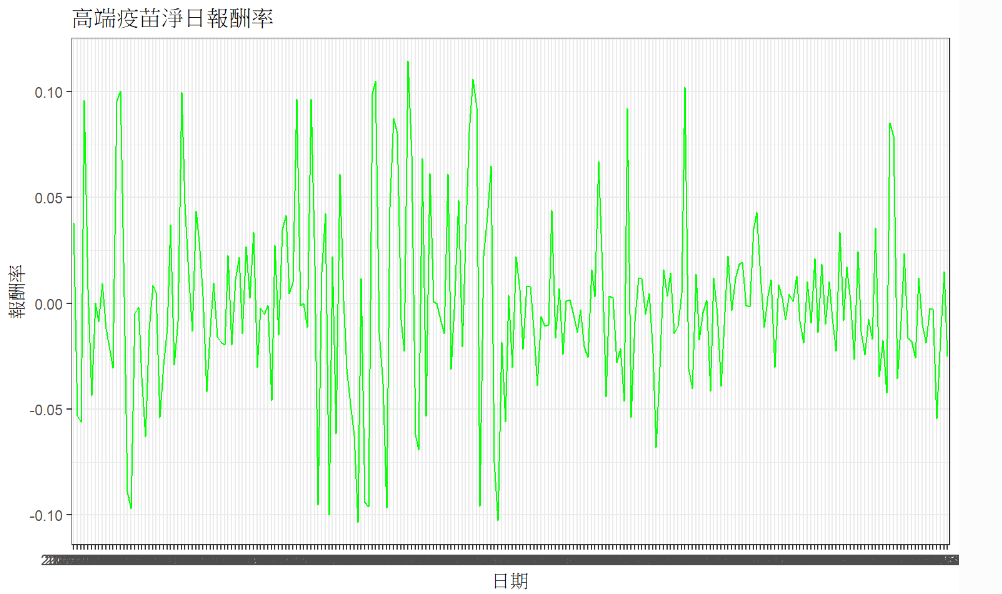

高端疫苗淨日報酬率

## Step 4 高端疫苗股價和COVID-19全球新增確診人數成高度相關性

**流程架構**

為了驗證高端疫苗股價和COVID-19全球新增確診人數的相關性，將兩者的關係描繪出**點狀圖**及進行**單變數迴歸分析**。

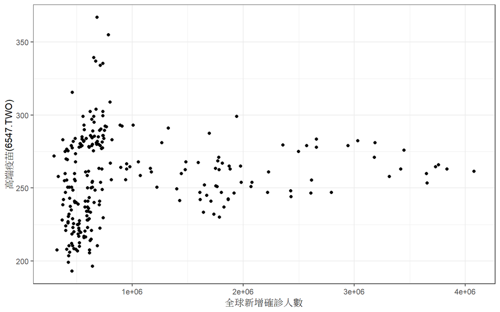

```
##
## Call:
## lm(formula = price ~ number, data = df2)
##
## Residuals:
##     Min      1Q  Median      3Q     Max
## -61.731 -19.773  -1.519  22.983 111.211
##
## Coefficients:
##              Estimate Std. Error t value Pr(>|t|)
## (Intercept) 2.526e+02  3.017e+00  83.729   <2e-16 ***
## number      4.691e-06  2.317e-06   2.025    0.044 *
## ---
## Signif. codes:  0 '***' 0.001 '**' 0.01 '*' 0.05 '.' 0.1 ' ' 1
##
## Residual standard error: 29.61 on 242 degrees of freedom
## Multiple R-squared:  0.01666,    Adjusted R-squared:  0.01259
## F-statistic:   4.1 on 1 and 242 DF,  p-value: 0.04399
```

## 結論與檢討

> 驗證一、高端疫苗可以代表生技業進行數據分析: *Fail*

`原因`：臺灣生技醫療業非常多元，主要分為製藥產業、應用生技業及醫療器材業三大類別，而高端疫苗的核心技術是細胞培養製程及疫苗的研發，屬於製藥業的生物製劑分支，佔生技醫療比例不大。除此之外，雖然高端疫苗因為和政府合作變得家喻戶曉，但實際上高端疫苗仍是上櫃公司。綜合上述，以高端疫苗一家公司來看整體生技業的局勢並不合適，但我們仍舊可以依後續程式流程觀察該公司是否獲利於COVID-19。

> 驗證三、高端疫苗股價受到COVID-19影響: *Fail*

`原因`： (1)歷史數據時間不夠長：只擷取一年股價和新增確診數作分析，股價可能因為短時間的事件波動，而無法看出長期的走勢，可以改用3~5年的歷史數據，或許會得到不一樣的結果。 (2)投資人的心態：雖然生技產業在疫情期間是具有話題性的題材，但是市場上大多數的投資人並非風險偏好者，還是傾向於將資金投入基本面較好的產業進行長線操作，如半導體業等。 (3)民眾對於高端疫苗的信心：雖然高端疫苗和政府合作，但是民眾普遍接種意願低，再加上缺乏國際認證，可能影響投資人決策。

**結論**

## 其他/附錄

**(1) Where you get your project ideas?**

從5月初臺灣疫情爆發之後，和COVID-19共存成為我們生活的一部分，除了學校改成遠距教學、口罩和酒精不離身外，周遭的親朋好友也開始很積極地去接種疫苗。對於施打疫苗的種類，每個人都有不同考量，雖然大部分的人都會選擇特別針對Omicron的mRNA疫苗，但是少部分害怕副作用的人還是會施打高端疫苗。「高端疫苗」一詞和其公司因為和政府合作一炮而紅，不經讓我好奇高端疫苗以及整個生技產業是否成為疫情下的大贏家？再加上上學期有修習投資學，對股市有些許概念，所以想以高端疫苗為主題，去探討其股價和疫情的關係。

**(2) What R techniques have been used?**

●網頁呈現 運用`rmdformats`套件中`readthedown`來設計整體頁面呈現方式

●資料處理

`read.csv`：讀取csv檔案

`as.xts`：將dataframe轉換成時間序列xts資料以方便處理

`runMean`：繪製均線圖的前置作業

`periodReturn`：計算日報酬率

`coredata`：將xts以matrix方式擷取

`cbind`：為dataframe新增欄位

●繪圖

`ggplot`：準備畫布

`geom_point`：繪製點狀圖

`geom_line`：繪製折線圖

`xlab`：標示X軸

`ylab`：標示Y軸

`theme_bw`：套用佈景主題

`chartSeries`：繪製股價K線走勢圖

`addTA`：繪製均線

`addADX`：繪製Directional Movement Index

`addROC`：繪製Rate Of Change to Chart

●迴歸分析

`lm`：進行單變數迴歸分析

**(3) How many new packages and functions are used?**

1.`ggplot2`：繪製點狀圖、折線圖等視覺化結果之套件

2.`TTR`：計算金融資產技術指標之套件

3.`quantmod`：金融資產技術分析回測套件並且整合TTR套件，繪製出漂亮的技術分析圖形

4.`DT`：呈現出可以調整排序的使用資料

5.`PerformanceAnalytics`：計算金融資產報酬績效指標之套件

6.`xts/zoo`：處理時間序列之套件

**(4) What is the most difficult part of your analysis?**

●xts和TTR、quantmod有些指令不相容

將dataframe轉換成xts繪製均線圖之後，原本想按指令繼續繪製出RSI、布林通道等，但有些指令無法使用xts操作，所以為了方便起見，便選擇可以和xts相容的ADX、ROC進行技術分析的繪製。

●高端疫苗股價日期和全球新增確診人數日期不同

因為股價有休市的關係，所以和全球新增確診人數的日期會有差距，如果日期不同則無法進行迴歸分析，因此首先要把兩份資料的日期處理成一樣的。

**使用資料**

1.高端疫苗(6547)一年股價歷史數據

|  | Date | Open | High | Low | Close | Adj.Close | Volume |
| --- | --- | --- | --- | --- | --- | --- | --- |
| 1 | 2021-06-01 | 315.5 | 315.5 | 315.5 | 315.5 | 315.5 | 1535000 |
| 2 | 2021-06-02 | 284 | 284 | 284 | 284 | 284 | 1512000 |
| 3 | 2021-06-03 | 256 | 256 | 256 | 256 | 256 | 1959000 |
| 4 | 2021-06-04 | 230.5 | 230.5 | 230.5 | 230.5 | 230.5 | 1948000 |
| 5 | 2021-06-07 | 207.5 | 207.5 | 207.5 | 207.5 | 207.5 | 2169000 |
| 6 | 2021-06-08 | 190.5 | 228 | 190.5 | 228 | 228 | 8639000 |
| 7 | 2021-06-09 | 250.5 | 250.5 | 250.5 | 250.5 | 250.5 | 7295000 |
| 8 | 2021-06-10 | 250.5 | 250.5 | 250.5 | 250.5 | 250.5 | 0 |
| 9 | 2021-06-11 | 275.5 | 275.5 | 275.5 | 275.5 | 275.5 | 346000 |
| 10 | 2021-06-15 | 303 | 303 | 248 | 283 | 283 | 9756000 |

[output cut: 234 more lines]

2.生技指數一年股價歷史數據

|  | Date | Open | High | Low | Close | Adj.Close | Volume |
| --- | --- | --- | --- | --- | --- | --- | --- |
| 1 | 2021-06-01 | 79 | 79.5 | 78.699997 | 79.099998 | 77.720062 | 279516 |
| 2 | 2021-06-02 | 80.5 | 83.099998 | 79.5 | 80.400002 | 78.997383 | 1143070 |
| 3 | 2021-06-03 | 80.400002 | 81.699997 | 79.5 | 80 | 78.604362 | 321055 |
| 4 | 2021-06-04 | 80 | 80.5 | 78 | 78.5 | 77.130531 | 458162 |
| 5 | 2021-06-07 | 79.300003 | 79.300003 | 76.5 | 78 | 76.639252 | 241000 |
| 6 | 2021-06-08 | 77.300003 | 77.800003 | 76.599998 | 77.199997 | 75.853203 | 994100 |
| 7 | 2021-06-09 | 77.199997 | 80.599998 | 77.199997 | 79.5 | 78.113083 | 834302 |
| 8 | 2021-06-10 | 80 | 80.199997 | 78.699997 | 78.800003 | 77.425301 | 259000 |
| 9 | 2021-06-11 | 78.599998 | 80.800003 | 78.599998 | 79.900002 | 78.506104 | 474200 |
| 10 | 2021-06-15 | 80.699997 | 80.699997 | 79.300003 | 80.099998 | 78.702614 | 288151 |

[output cut: 234 more lines]

3.台股大盤指數一年歷史數據

|  | Date | Open | High | Low | Close | Adj.Close | Volume |
| --- | --- | --- | --- | --- | --- | --- | --- |
| 1 | 2021/6/1 | 17098.49023 | 17184.30078 | 17060.44922 | 17162.38086 | 17162.38086 | 7821200 |
| 2 | 2021/6/2 | 17192.91016 | 17274.66016 | 17056.41992 | 17165.03906 | 17165.03906 | 9368700 |
| 3 | 2021/6/3 | 17201.30078 | 17311.2793 | 17198.89063 | 17246.16016 | 17246.16016 | 8355400 |
| 4 | 2021/6/4 | 17225.06055 | 17225.06055 | 17084.49023 | 17147.41016 | 17147.41016 | 8595000 |
| 5 | 2021/6/7 | 17176.08984 | 17189.23047 | 16775.84961 | 17083.91016 | 17083.91016 | 8683700 |
| 6 | 2021/6/8 | 17094.33984 | 17181.51953 | 17056.5293 | 17076.21094 | 17076.21094 | 5658700 |
| 7 | 2021/6/9 | 17082.51953 | 17082.51953 | 16907.42969 | 16966.2207 | 16966.2207 | 6310000 |
| 8 | 2021/6/10 | 17024.53906 | 17159.2207 | 16978.00977 | 17159.2207 | 17159.2207 | 6582700 |
| 9 | 2021/6/11 | 17200.44922 | 17278.55078 | 17193.60938 | 17213.51953 | 17213.51953 | 6154800 |
| 10 | 2021/6/15 | 17279.69922 | 17371.28906 | 17279.69922 | 17371.28906 | 17371.28906 | 6317500 |

[output cut: 234 more lines]

4.COVID-19全球確診人數一年歷史數據

|  | id | iso_code | 洲名 | 國家 | 日期 | 總確診數 | 新增確診數 | 七天移動平均新增確診數 | 總死亡數 | 新增死亡數 | 七天移動平均新增死亡數 | 每百萬人確診數 | 每百萬人死亡數 | 傳染率 | 新增檢驗件數 | 總檢驗件數 | 每千人檢驗件數 | 七天移動平均新增檢驗件數 | 陽性率 | 每確診案例相對檢驗數量 | 疫苗總接種總劑數 | 疫苗總接種人數 | 疫苗新增接種劑數 | 七天移動平均疫苗新增接種劑數 | 每百人接種疫苗劑數 | 每百人接種疫苗人數 | 疫情控管指數 | 總人口數 | 中位數年紀 | … |
| --- | --- | --- | --- | --- | --- | --- | --- | --- | --- | --- | --- | --- | --- | --- | --- | --- | --- | --- | --- | --- | --- | --- | --- | --- | --- | --- | --- | --- | --- | --- |
| 1 | 181033 | OWID_WRL | 全球 | 全球 | 2022/5/30 | 529008919 | 402621 | 466297.857 | 6291029 | 1247 | 1483.714 | 67176.028 | 798.864 | 0.95 | 0 | 0 | 0 | 0 | 0 | 0 | 2147483647 | 2147483647 | 5449038 | 7016714 | 150.38 | 65.94 | 0 | 2147483647 | 30.9 | … |
| 2 | 181032 | OWID_WRL | 全球 | 全球 | 2022/5/29 | 528606298 | 275137 | 482197 | 6289782 | 547 | 1511.429 | 67124.901 | 798.706 | 0.94 | 0 | 0 | 0 | 0 | 0 | 0 | 2147483647 | 2147483647 | 5207697 | 7258641 | 150.31 | 65.92 | 0 | 2147483647 | 30.9 | … |
| 3 | 181031 | OWID_WRL | 全球 | 全球 | 2022/5/28 | 528331161 | 285786 | 491350.143 | 6289235 | 713 | 1525.429 | 67089.963 | 798.636 | 0.94 | 0 | 0 | 0 | 0 | 0 | 0 | 2147483647 | 2147483647 | 6831581 | 7383530 | 150.2 | 65.79 | 0 | 2147483647 | 30.9 | … |
| 4 | 181030 | OWID_WRL | 全球 | 全球 | 2022/5/27 | 528045375 | 567545 | 504019 | 6288522 | 1978 | 1576.286 | 67053.673 | 798.546 | 0.93 | 0 | 0 | 0 | 0 | 0 | 0 | 2147483647 | 2147483647 | 9246497 | 7423616 | 150.13 | 65.78 | 0 | 2147483647 | 30.9 | … |
| 5 | 181029 | OWID_WRL | 全球 | 全球 | 2022/5/26 | 527477830 | 518838 | 510553.429 | 6286545 | 1522 | 1574.714 | 66981.603 | 798.295 | 0.92 | 0 | 0 | 0 | 0 | 0 | 0 | 2147483647 | 2147483647 | 7594019 | 7352001 | 150.03 | 65.77 | 0 | 2147483647 | 30.9 | … |
| 6 | 181028 | OWID_WRL | 全球 | 全球 | 2022/5/25 | 526963500 | 633671 | 521262.571 | 6285109 | 2630 | 1615.714 | 66916.291 | 798.113 | 0.92 | 0 | 0 | 0 | 0 | 0 | 0 | 2147483647 | 2147483647 | 7544125 | 7519533 | 149.94 | 65.75 | 0 | 2147483647 | 30.9 | … |
| 7 | 181027 | OWID_WRL | 全球 | 全球 | 2022/5/24 | 526329829 | 580487 | 536453.429 | 6282480 | 1749 | 1581 | 66835.825 | 797.779 | 0.92 | 0 | 0 | 0 | 0 | 0 | 0 | 2147483647 | 2147483647 | 7567963 | 7670854 | 149.87 | 65.74 | 0 | 2147483647 | 30.9 | … |
| 8 | 181026 | OWID_WRL | 全球 | 全球 | 2022/5/23 | 525749342 | 513915 | 538572 | 6280736 | 1441 | 1605.143 | 66762.112 | 797.557 | 0.93 | 0 | 0 | 0 | 0 | 0 | 0 | 2147483647 | 2147483647 | 6836884 | 7751800 | 149.76 | 65.73 | 0 | 2147483647 | 30.9 | … |
| 9 | 181025 | OWID_WRL | 全球 | 全球 | 2022/5/22 | 525265080 | 339209 | 551553.857 | 6279296 | 645 | 1645.143 | 66700.618 | 797.374 | 0.95 | 0 | 0 | 0 | 0 | 0 | 0 | 2147483647 | 2147483647 | 6143660 | 7792754 | 149.7 | 65.72 | 0 | 2147483647 | 30.9 | … |
| 10 | 181024 | OWID_WRL | 全球 | 全球 | 2022/5/21 | 524925957 | 374468 | 556400 | 6278652 | 1069 | 1642.857 | 66657.554 | 797.293 | 0.96 | 0 | 0 | 0 | 0 | 0 | 0 | 2147483647 | 2147483647 | 7173807 | 7733055 | 149.49 | 65.66 | 0 | 2147483647 | 30.9 | … |

[output cut: 354 more lines]

**延伸補充**

因受限於8頁project內容，部分程式結果移至其他/附錄呈現

**台股大盤指數走勢圖**

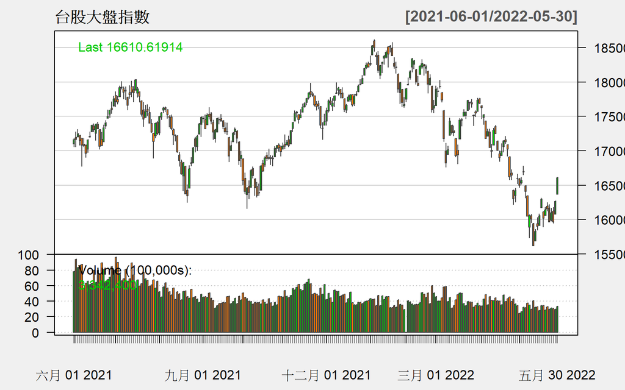

**高端疫苗和台股大盤指數相關性檢驗**

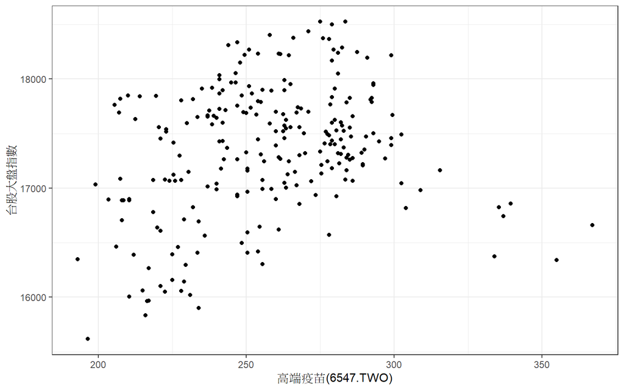

```
##
## Call:
## lm(formula = tw ~ medigen, data = representative.df2)
##
## Residuals:
##      Min       1Q   Median       3Q      Max
## -1495.16  -332.29   -17.83   420.14  1090.01
##
## Coefficients:
##              Estimate Std. Error t value Pr(>|t|)
## (Intercept) 16058.748    323.242  49.680  < 2e-16 ***
## medigen         5.009      1.248   4.015 7.94e-05 ***
## ---
## Signif. codes:  0 '***' 0.001 '**' 0.01 '*' 0.05 '.' 0.1 ' ' 1
##
## Residual standard error: 579.6 on 242 degrees of freedom
## Multiple R-squared:  0.06244,    Adjusted R-squared:  0.05857
## F-statistic: 16.12 on 1 and 242 DF,  p-value: 7.944e-05
```

**高端疫苗vs.台股大盤指數報酬率比較**

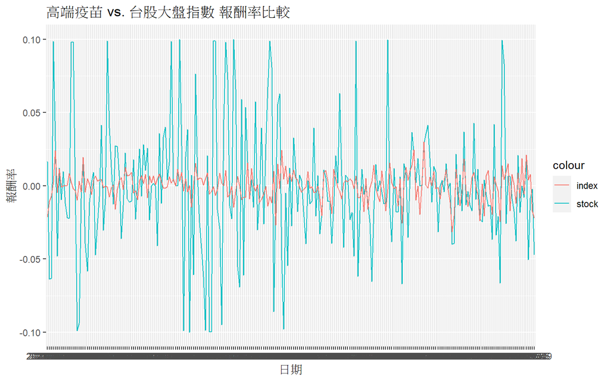

**添加ADX、ROC的技術分析圖**

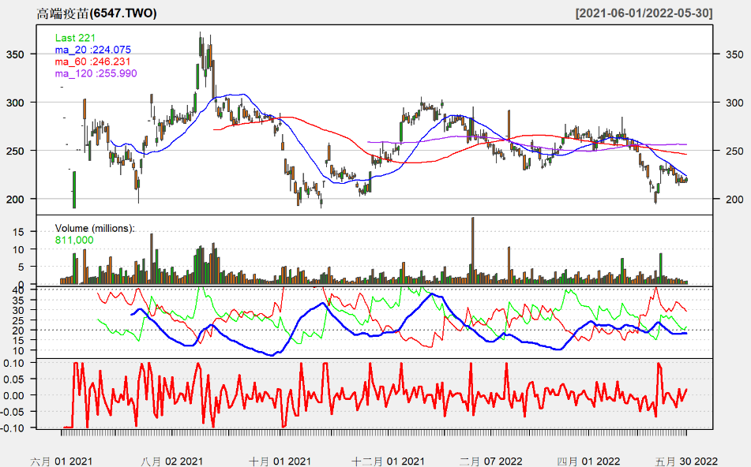

完整高端疫苗技術分析圖